# Rendu Parcoursup

AGOSSADOU Guerin, CHAQUIQ ELBADRE Youssef, MOUISSOU Lina

2025-12-09

# Installation du package `M2algorithmique`

```r
if (!requireNamespace("M2algorithmique", quietly = TRUE)) {
  if (!requireNamespace("remotes", quietly = TRUE))
    install.packages("remotes")
  remotes::install_github("vrunge/M2algorithmique")
}

library(M2algorithmique)
```

# **I - Introduction**

Ce projet porte sur un **problème d’optimisation discrète** inspiré du fonctionnement de **Parcoursup**, la plateforme d’attribution des formations aux étudiants.

L’objectif est de modéliser la manière dont les formations sont attribuées aux candidats, en prenant en compte différentes **contraintes**.

# **II - Formulation du problème**

Le système Parcoursup vise à attribuer des **formations** à des **étudiants** selon leurs préférences et les capacités d’accueil des établissements.  
On peut modéliser ce processus comme un **problème d’optimisation discrète d’affectation**.

On définit les ensembles suivants :

- **Étudiants**
  $$E = \{(e_1,p_1,n_1), (e_2,p_2,n_2), ..., (e_n,p_n,n_n)\}$$
  où :
  → $e_i$ : l’élève $i$
  → $p_i$ : sa liste de préférence des formations
  → $n_{i}$ : sa moyenne
- **Formations** :
  $$F = \{ (f_1, c_1, n_{f_1}), (f_2, c_2, n_{f_2}), \dots, (f_m, c_m,
  n_{f_m}) \}$$
  où :
  → $f_i$ : la formation $i$
  → $c_i$ : sa capacité maximale
  → $n_{f_i}$ : la note minimale requise pour y accéder .

## → Contraintes du problème

Nous imposons les contraintes suivantes :

1. **Unicité de l’affectation pour chaque étudiant :**
   $$\sum_{j=1}^{m} x_{ij} \leq 1 \quad \forall i$$
   → Un étudiant ne peut recevoir **qu’une seule formation**.
2. **Capacité limitée des formations :**
   $$\sum_{i=1}^{n} x_{ij} \leq c_j \quad \forall j$$
   → Chaque formation *j* ne peut accueillir que $c_j$ étudiants.
3. **Note minimale requise :**
   - Chaque formation peut exiger une **note minimale** pour être admis.
   - Formulé mathématiquement :

$$x_{ij} = 0 \quad \text{si } n_i < n_{f_j}, \quad \forall i,j$$

→ Un étudiant ne peut être affecté à une formation que si sa note est suffisante. 4. **Score combinant préférence et mérite académique :**

Afin de mieux refléter un comportement réaliste d’allocation (inspiré de Parcoursup), nous introduisons un score global défini comme une combinaison linéaire :

$$s_{ij} = \alpha \, p_{ij} + \beta \, n_i ,$$

où :

- $p_{ij}$ : préférence déclarée de l’étudiant $i$ pour la formation $j$,
- $n_i$ : note de l’étudiant $i$,
- $\alpha, \beta \ge 0$ : coefficients permettant de pondérer l’importance de la préférence et du mérite.

## → Objectif

Nous cherchons à maximiser la somme des scores combinés :

$$\text{Maximiser} \quad
S = \sum_{i=1}^{n} \sum_{j=1}^{m} s_{ij} \, x_{ij}$$
### Fonction de construction de la matrice des scores

Avant de commencer l’implémentation des méthodes, on définit la fonction qui nous permettra par la suite de calculer les scores à partir des préférences et des notes des étudiants :

```r
build_scores <- function(prefs, notes, alpha = 100, beta = 1) {
  n <- nrow(prefs)
  m <- ncol(prefs)
  scores <- matrix(0, n, m)
  for (i in 1:n) {
    for (j in 1:m) {
      scores[i, j] <- alpha * prefs[i, j] + beta * notes[i]
    }
  }
  scores
}
```

# III - **Résolution du problème**

## 1) → Solution naïve :

La méthode naïve consiste à essayer toutes les affectations possibles puis à choisir celle qui donne la meilleure valeur de la fonction objectif parmi celles qui respectent les contraintes.

On note :

- n = nombre d’étudiants,
- m = nombre de formations, Chaque étudiant peut être affecté à une des $m$ formations, ou rester non affecté.

Le nombre total de combinaisons possibles est donc :

$$(m + 1)^n$$

Ensuite, on sélectionne l’affectation qui **maximise le score total** tout en respectant l’ensemble des contraintes.

- L’implémentation de la méthode naïve :

```r
solution_naive_simple <- function(scores, capacities, notes, notes_min, allow_unassigned = TRUE) {
  n <- nrow(scores) # Nombre d'étudiants
  m <- ncol(scores) # Nombre de formations

  # Options possibles pour chaque étudiant : 0 = non assigné, 1..m = formation
  options <- if (allow_unassigned) 0:m else 1:m

  # Génère toutes les combinaisons possibles d'affectations
  all_assignments <- expand.grid(replicate(n, options, simplify = FALSE))
  all_assignments <- as.matrix(all_assignments)

  best_score <- -Inf
  best_assign <- NULL

  for (k in 1:nrow(all_assignments)) {
    assign <- all_assignments[k, ]
    valid <- TRUE
    score <- 0
    counts <- integer(m)

    for (i in 1:n) {
      j <- assign[i]
      if (j == 0) next  # étudiant non assigné
      if (notes[i] < notes_min[j]) { valid <- FALSE; break }
      counts[j] <- counts[j] + 1
      if (counts[j] > capacities[j]) { valid <- FALSE; break }
      score <- score + scores[i, j]
    }

    if (valid && score > best_score) {
      best_score <- score
      best_assign <- assign
    }
  }

  return(list(best_score = best_score, best_assign = best_assign))

}
```

## 2) → Solution Branch and Bound :

La méthode *Branch and Bound* est une méthode exacte qui permet d’explorer l’espace des solutions de manière beaucoup plus efficace que la solution naïve.  
Au lieu de tester toutes les affectations possibles, elle construit un **arbre de décision** où chaque niveau correspond à un étudiant, et chaque branche représente une décision d’affectation (choisir une formation ou ne pas en attribuer).

### i) Structure de l’arbre

Pour un problème avec $n$ étudiants et $m$ formations, l’arbre possède :

- $n$ niveaux (un niveau par étudiant),
- $m + 1$ branches par niveau (les $m$ formations possibles + l’option “non affecté”),
- les feuilles représentent des solutions complètes (tous les étudiants traités).

Comme la méthode naïve, le Branch and Bound s’appuie sur cet arbre, mais il n’explore pas toutes les branches.

### ii) Principe du *Branch*

Pour chaque étudiant $i$, l’algorithme essaie toutes les décisions possibles :

- ne pas l’affecter (si autorisé),
- l’affecter à chacune des formations admissibles (note suffisante + capacité restante).

Chaque décision crée une nouvelle branche de l’arbre.

### iii) Principe du *Bound* (élagage des branches inutiles)

Avant d’explorer une branche, on calcule une **borne supérieure** (upper bound) :

$$UB(i) = S_i + \sum_{k=i}^{n} s_k^{\max}$$

où $S_i$ est le score courant, et $s_k^{\max}$ désigne le meilleure score possible pour l’étudiant $k$, parmi les formations pour lesquelles il satisfait la note minimale.

Cette borne représente le **meilleur score théorique encore atteignable** à partir de cet état partiel.

Si :

$$UB(i) \le S_{\text{best}},$$

alors :

- la branche ne pourra **jamais** mener à une solution optimale,
- l’algorithme coupe immédiatement cette branche (*pruning*).

Sinon, on continue l’exploration récursive de la branche.

Ce mécanisme permet d’éviter des milliers de calculs inutiles.

### iv) Optimalité garantie

Le Branch and Bound ne coupe que les branches dont on sait qu’elles ne peuvent pas contenir l’optimum.  
Il explore donc beaucoup moins de solutions que la méthode naïve **tout en garantissant exactement la même solution optimale**.

```r
solution_bb <- function(scores, capacities, notes, notes_min) {
  n <- nrow(scores)
  m <- ncol(scores)

  # Meilleur score possible par étudiant (pour la borne sup)
  best_score_per_student <- numeric(n)
  for (i in 1:n) {
    vals <- scores[i, ]
    # On annule les formations où la note minimale n'est pas respectée
    vals[notes[i] < notes_min] <- 0
    best_score_per_student[i] <- max(vals)
  }

  best_score  <- -Inf
  best_assign <- rep(0L, n)

  dfs <- function(i, current_score, assign_vec, capacities_left) {
    # Cas terminal : tous les étudiants ont été traités
    if (i > n) {
      if (current_score > best_score) {
        best_score  <<- current_score
        best_assign <<- assign_vec
      }
      return()
    }

    # Borne supérieure (upper bound)
    ub <- current_score + sum(best_score_per_student[i:n])
    if (ub <= best_score) return()

    ## 1) Option : l'étudiant i n'est pas affecté
    assign_vec[i] <- 0L
    dfs(i + 1, current_score, assign_vec, capacities_left)

    ## 2) Options : l'affecter à une formation admissible
    for (j in 1:m) {
      # Contrainte de note minimale
      if (notes[i] < notes_min[j]) next
      # Contrainte de capacité
      if (capacities_left[j] <= 0) next

      assign_vec2 <- assign_vec
      assign_vec2[i] <- j

      cap2 <- capacities_left
      cap2[j] <- cap2[j] - 1

      dfs(i + 1, current_score + scores[i, j], assign_vec2, cap2)
    }
  }

  dfs(1, 0, rep(0L, n), capacities)

  list(best_score = best_score, best_assign = best_assign)
}
```

## 3) → Solution par l’heuristique gloutonne :

La méthode gloutonne constitue une approche simple et rapide pour obtenir une affectation réalisable.  
Contrairement aux méthodes exactes (Naïve et Branch and Bound), elle procède par **choix locaux optimaux** sans garantir l’optimalité globale.

Le principe consiste à examiner **tous les couples possibles** (étudiant, formation), à les évaluer via leur score, puis à sélectionner les couples les plus intéressants en premier, tant que les contraintes sont satisfaites.

### **i) Construction des couples admissibles**

Pour chaque étudiant $e_i$ et chaque formation $f_j$, on peut former un couple $(i,j)$ associé au score :

$$s_{ij} = \alpha p_{ij} + \beta n_i.$$

Un couple n’est **admissible** que si la contrainte de note minimale est respectée :

$$n_i \ge n_{f_j}.$$

On définit l’ensemble des couples admissibles :

$$A = \{ (i,j) \mid n_i \ge n_{f_j} \}.$$

### **ii) Tri des couples par score décroissant**

On trie ensuite les couples de $A$ selon leur score :

$$(i_1,j_1), (i_2,j_2),\dots,(i_K,j_K)
\quad \text{tels que } s_{i_1 j_1} \ge s_{i_2 j_2} \ge \cdots \ge s_{i_K
j_K}.$$

Cette liste ordonnée représente l’ordre dans lequel les couples seront examinés par l’algorithme.

### **iii) Règle gloutonne d’affectation**

On initialise :

- les capacités restantes : $c_j^{(0)} = c_j$,
- la matrice d’affectation : $x_{ij} = 0$.

Puis, pour chaque couple $(i_k,j_k)$ dans l’ordre décroissant des scores :

- si l’étudiant $e_{i_k}$ n’a encore reçu **aucune formation** :
  $$\sum_{j=1}^m x_{i_k j} = 0,$$
- et si la formation $f_{j_k}$ possède encore au moins une place :
  $$c_{j_k}^{(k-1)} > 0,$$

alors on effectue l’affectation :

$$x_{i_k j_k} = 1,
\qquad
c_{j_k}^{(k)} = c_{j_k}^{(k-1)} - 1.$$

Sinon, le couple est ignoré.

L’algorithme termine lorsque tous les couples ont été examinés.

Cette stratégie suit donc la logique :

À chaque étape, on choisit le couple étudiant–formation réalisable avec le score le plus élevé.

```r
solution_greedy <- function(scores, capacities, notes, notes_min) {
  n <- nrow(scores)
  m <- ncol(scores)

  # Liste de tous les couples (i, j)
  pairs <- which(matrix(TRUE, n, m), arr.ind = TRUE)  # matrice avec colonnes i, j

  # Score associé à chaque couple (i, j)
  score_vec <- scores[pairs]

  # On enlève les couples qui ne respectent pas la note minimale
  admissible <- notes[pairs[, 1]] >= notes_min[pairs[, 2]]
  pairs     <- pairs[admissible, , drop = FALSE]
  score_vec <- score_vec[admissible]

  # On trie les couples par score décroissant
  ord      <- order(score_vec, decreasing = TRUE)
  pairs    <- pairs[ord, , drop = FALSE]
  score_vec <- score_vec[ord]

  # On construit l'affectation gloutonne
  assign   <- integer(n)        # 0 = non assigné
  cap_left <- capacities
  total_score <- 0

  for (k in seq_len(nrow(pairs))) {
    i <- pairs[k, 1]  # étudiant
    j <- pairs[k, 2]  # formation

    # Si l'étudiant a déjà une formation, on saute
    if (assign[i] != 0) next

    # Si la formation est pleine, on saute
    if (cap_left[j] <= 0) next

    # Sinon, on affecte
    assign[i]   <- j
    cap_left[j] <- cap_left[j] - 1
    total_score <- total_score + score_vec[k]
  }

  list(best_score = total_score, best_assign = assign)
}
```

## 4) → Solution par programmation dynamique (DP) :

La dernière approche consiste à utiliser une **programmation dynamique** pour éviter de recalculer plusieurs fois les mêmes sous-problèmes.  
L’idée est de traiter les étudiants un par un (dans l’ordre $i = 1,\dots,n$), en mémorisant, pour chaque état de capacités restantes, le **meilleur score** encore atteignable.

### **i) Définition des sous-problèmes**

On note :

- $i \in \{1,\dots,n\}$ : indice de l’étudiant courant $e_i$,
- $\mathbf{c} = (c_1,\dots,c_m)$ : vecteur des capacités **restantes** pour chaque formation $f_j$.

On définit la fonction de valeur :

$$V(i, \mathbf{c})
= \text{score maximal total que l’on peut encore obtenir en affectant
les étudiants } e_i, e_{i+1}, \dots, e_n$$
sachant que les capacités restantes sont $\mathbf{c}$.

L’objectif global est alors $V(1, (c_1,\dots,c_m))$.

### **ii) Relation de récurrence**

Pour un étudiant $e_i$, deux types de décisions sont possibles :

1. **Ne pas l’affecter** (il reste non assigné) :
   on passe à l’étudiant suivant avec les mêmes capacités :
   $$\text{Option 0 :} \quad V(i,\mathbf{c}) \ge V(i+1,\mathbf{c}).$$
2. **L’affecter à une formation admissible** $f_j$ :
   - condition de note minimale :
     $$n_i \ge n_{f_j},$$
   - condition de capacité :
     $$c_j > 0.$$

   Si ces conditions sont satisfaites, on peut affecter $e_i$ à $f_j$.
   Le score obtenu est alors :
   $$s_{ij} + V\big(i+1,\ (c_1,\dots,c_j - 1,\dots,c_m)\big).$$

La relation de récurrence complète s’écrit donc :

$$V(i,\mathbf{c})
=
\max \left(
\underbrace{V(i+1,\mathbf{c})}_{\text{non affecté}},
\
\max_{\substack{1 \le j \le m \\ n_i \ge n_{f_j},\, c_j > 0}}
\big\{ s_{ij} + V(i+1,\mathbf{c} - \mathbf{e}_j) \big\}
\right),$$

où $\mathbf{e}_j$ est le vecteur unitaire qui enlève 1 à la capacité de la formation $f_j$.

### **iii) Condition initiale**

Lorsque tous les étudiants ont été traités ($i > n$), il n’y a plus rien à affecter :

$$V(n+1, \mathbf{c}) = 0 \quad \text{pour tout vecteur de capacités }
\mathbf{c}.$$

### **iv) Intérêt de la programmation dynamique**

Sans mémorisation, cette approche récursive reviendrait à explorer un grand arbre de décisions, comme pour le Branch and Bound.  
La programmation dynamique consiste à **mémoriser** les valeurs de $V(i,\mathbf{c})$ déjà calculées, afin de ne jamais résoudre deux fois le même sous-problème.

Concrètement, on utilise une table indexée par :

- l’indice de l’étudiant $i$,
- le vecteur des capacités restantes $\mathbf{c}$.

Dès qu’un sous-problème $(i,\mathbf{c})$ a été résolu, on stocke le meilleur score trouvé.  
Si le même état réapparaît plus tard, on le réutilise directement.

```r
solution_dp <- function(scores, capacities, notes, notes_min) {
  n <- nrow(scores)
  m <- ncol(scores)

  # Mémoisation des sous-problèmes : clé = (i, cap_1, ..., cap_m)
  memo <- new.env(hash = TRUE, parent = emptyenv())

  dp <- function(i, cap_left) {
    # i : indice de l'étudiant courant
    # cap_left : vecteur des capacités restantes

    # Condition terminale : tous les étudiants ont été traités
    if (i > n) {
      return(list(score = 0, assign = integer(0)))
    }

    # Clé de mémoisation
    key <- paste(i, paste(cap_left, collapse = ","), sep = "|")
    if (!is.null(memo[[key]])) {
      return(memo[[key]])
    }

    # Option 0 : l'étudiant i reste non assigné
    best_score    <- -Inf
    best_assign_i <- NULL

    # Cas "non affecté"
    res_skip <- dp(i + 1, cap_left)
    best_score    <- res_skip$score
    best_assign_i <- c(0L, res_skip$assign)

    # Cas "affecté à une formation admissible"
    for (j in 1:m) {
      # Contrainte de note minimale
      if (notes[i] < notes_min[j]) next
      # Contrainte de capacité
      if (cap_left[j] <= 0) next

      new_cap <- cap_left
      new_cap[j] <- new_cap[j] - 1

      res_next <- dp(i + 1, new_cap)
      cand_score <- scores[i, j] + res_next$score
      cand_assign <- c(j, res_next$assign)

      if (cand_score > best_score) {
        best_score    <- cand_score
        best_assign_i <- cand_assign
      }
    }

    # Si aucune option ne donne un score > -Inf, on force 0
    if (best_score == -Inf) {
      best_score    <- 0
      best_assign_i <- c(0L, integer(0))
    }

    out <- list(score = best_score, assign = best_assign_i)
    memo[[key]] <- out
    return(out)
  }

  res <- dp(1, capacities)

  list(
    best_score  = res$score,
    best_assign = res$assign
  )
}
```

# IV - **Analyse de la complexité en temps**

## **1. Solution naïve**

**Principe** : Énumération exhaustive de toutes les affectations possibles.

**Complexité** :
$$\boxed{O((m+1)^n)}$$

**Justification** :

- Chaque étudiant peut être affecté à l’une des $m$ formations ou rester non affecté : $(m+1)$ choix
- Pour $n$ étudiants : $(m+1)^n$ combinaisons possibles
- Pour chaque combinaison, on vérifie les contraintes en $O(n)$
- **Complexité totale** : $O(n \cdot (m+1)^n) = O((m+1)^n)$ (le terme exponentiel domine)

**Type** : Exponentielle — impraticable dès que $n$ dépasse 10-15.

## **2. Branch and Bound**

**Principe** : Exploration d’un arbre de décision avec élagage (*pruning*) des branches non prometteuses.

**Complexité dans le pire cas** :
$$\boxed{O((m+1)^n)}$$

**Complexité en pratique** :
$$\boxed{O(k \cdot (m+1)^d) \text{ où } d \ll
n}$$

**Justification** :

- **Pire cas** : Si aucune branche n’est élaguée, on explore tout l’arbre → identique à la solution naïve
- **Cas moyen** : Le calcul de la borne supérieure ($O(n)$ par nœud) permet d’élaguer une grande partie de l’arbre
- Le nombre de nœuds explorés dépend fortement de la qualité de la borne et de la structure des données
- En pratique, l’élagage réduit drastiquement l’espace de recherche : $k \ll (m+1)^n$

**Type** : Exponentielle dans le pire cas, mais **beaucoup plus efficace** que la solution naïve en pratique.

## **3. Heuristique gloutonne**

**Principe** : Tri des couples (étudiant, formation) par score décroissant, puis affectation gloutonne.

**Complexité** :
$$\boxed{O(nm \log(nm))}$$

**Justification** :

- Construction des couples admissibles : $O(nm)$
- Tri des couples par score : $O(nm \log(nm))$
- Parcours des couples pour l’affectation : $O(nm)$
- **Complexité totale** : $O(nm \log(nm))$ (dominée par le tri)

**Type** : Polynomiale — **très rapide**, mais **pas de garantie d’optimalité**.

## **4. Programmation dynamique (DP)**

**Principe** : Mémorisation des sous-problèmes $(i, \mathbf{c})$.

**Complexité** :
$$\boxed{O\left(n \cdot m \cdot \prod_{j=1}^m (c_j
+ 1)\right)}$$

**Justification** :

- Nombre d’états possibles : $n$ étudiants $\times$ $\prod_{j=1}^m (c_j + 1)$ configurations de capacités
- Pour chaque état, on teste au plus $m$ formations : $O(m)$
- **Complexité totale** : $O\left(n \cdot m \cdot \prod_{j=1}^m (c_j + 1)\right)$

Si toutes les capacités sont identiques ($c_j = C$), cela devient :
$$O(n \cdot m \cdot (C+1)^m)$$

**Type** : **Pseudo-polynomiale** (exponentielle en $m$, mais polynomiale si $m$ est petit et $C$ modéré).

## **Tableau récapitulatif**

| Algorithme | Complexité en temps | Type |
| --- | --- | --- |
| **Naïve** | $O((m+1)^n)$ | Exponentielle |
| **Branch & Bound** | $O((m+1)^n)$ (pire cas) $O(k \cdot (m+1)^d)$ (pratique, $d \ll n$) | Exponentielle (élagage efficace) |
| **Gloutonne** | $O(nm \log(nm))$ | Polynomiale |
| **Prog. Dynamique** | $O\left(n \cdot m \cdot \prod_{j=1}^m (c_j+1)\right)$ | Pseudo-polynomiale |

# V - **Génération de données et visualisation des résultats**

## **1. Fonction de génération de données**

Nous créons une fonction pour générer des instances de test avec différentes caractéristiques :

```r
generate_instance <- function(n_students, n_formations, seed = 123) {
  set.seed(seed)

  # Génération des notes des étudiants (entre 8 et 20)
  notes <- runif(n_students, min = 0, max = 20)

  # Génération des capacités des formations (entre 1 et n_students/2)
  capacities <- sample(1:max(1, floor(n_students/2)), n_formations, replace = TRUE)

  # Génération des notes minimales requises (entre 8 et 16)
  notes_min <- runif(n_formations, min = 8, max = 16)

  # Génération des préférences (rang de 1 à n_formations)
  prefs <- t(replicate(n_students, sample(1:n_formations, n_formations)))

  # Construction de la matrice des scores
  scores <- build_scores(prefs, notes, alpha = 100, beta = 1)

  list(
    scores = scores,
    capacities = capacities,
    notes = notes,
    notes_min = notes_min,
    prefs = prefs,
    n_students = n_students,
    n_formations = n_formations
  )
}
```

## **2. Cas de test**

```r
# Compare toutes les méthodes sur UNE instance donnée
compare_methods_one_instance <- function(instance) {
  res <- list()

  # Naïve
  res$naive <- solution_naive_simple(
    instance$scores, instance$capacities,
    instance$notes, instance$notes_min
  )

  # Branch & Bound
  res$bb <- solution_bb(
    instance$scores, instance$capacities,
    instance$notes, instance$notes_min
  )

  # Programmation dynamique
  res$dp <- solution_dp(
    instance$scores, instance$capacities,
    instance$notes, instance$notes_min
  )

  # Gloutonne
  res$greedy <- solution_greedy(
    instance$scores, instance$capacities,
    instance$notes, instance$notes_min
  )

  data.frame(
    Methode = c("Naive", "BB", "DP", "Greedy"),
    Score   = c(res$naive$best_score,
                res$bb$best_score,
                res$dp$best_score,
                res$greedy$best_score)
  )
}
inst_test <- generate_instance(n_students = 8, n_formations = 3, seed = 42)
compare_methods_one_instance(inst_test)
```

```
##   Methode    Score
## 1   Naive 1491.595
## 2      BB 1491.595
## 3      DP 1491.595
## 4  Greedy 1391.595
```

# Cas ou la méthode approchée performe aussi bien que les méthodes exactes :

```r
find_case_greedy_equal <- function(n_students = 8, n_formations = 3,
                                   max_seed = 1000) {
  for (s in 1:max_seed) {
    inst <- generate_instance(n_students, n_formations, seed = s)

    # On compare les scores des méthodes
    df <- compare_methods_one_instance(inst)

    score_opt    <- max(df$Score[ df$Methode %in% c("Naive", "BB", "DP") ], na.rm = TRUE)
    score_greedy <- df$Score[df$Methode == "Greedy"]

    # Cas où Greedy = optimal
    if (!is.na(score_greedy) && abs(score_greedy - score_opt) < 1e-9) {
      cat("Trouvé : seed =", s, "\n")
      print(df)

      # ===== MESURE DES TEMPS =====
      safe_time <- function(fun) {
        t <- system.time( invisible(fun()) )
        as.numeric(t[["elapsed"]])
      }

      t_naive  <- safe_time(function() solution_naive_simple(
        inst$scores, inst$capacities, inst$notes, inst$notes_min
      ))
      t_bb     <- safe_time(function() solution_bb(
        inst$scores, inst$capacities, inst$notes, inst$notes_min
      ))
      t_dp     <- safe_time(function() solution_dp(
        inst$scores, inst$capacities, inst$notes, inst$notes_min
      ))
      t_greedy <- safe_time(function() solution_greedy(
        inst$scores, inst$capacities, inst$notes, inst$notes_min
      ))

      times_df <- data.frame(
        Methode = c("Naive", "BB", "DP", "Greedy"),
        Temps_s = c(t_naive, t_bb, t_dp, t_greedy)
      )

      cat("\nTemps d'exécution (en secondes) sur cette instance (Greedy optimal) :\n")
      print(times_df)

      return(list(
        seed     = s,
        instance = inst,
        scores   = df,
        times    = times_df
      ))
    }
  }
  cat("Aucun cas trouvé (augmenter max_seed).\n")
  NULL
}

case_equal <- find_case_greedy_equal(n_students = 8, n_formations = 3, max_seed = 500)
```

```
## Trouvé : seed = 1
##   Methode    Score
## 1   Naive 1479.698
## 2      BB 1479.698
## 3      DP 1479.698
## 4  Greedy 1479.698
##
## Temps d'exécution (en secondes) sur cette instance (Greedy optimal) :
##   Methode Temps_s
## 1   Naive    0.16
## 2      BB    0.00
## 3      DP    0.00
## 4  Greedy    0.00
```

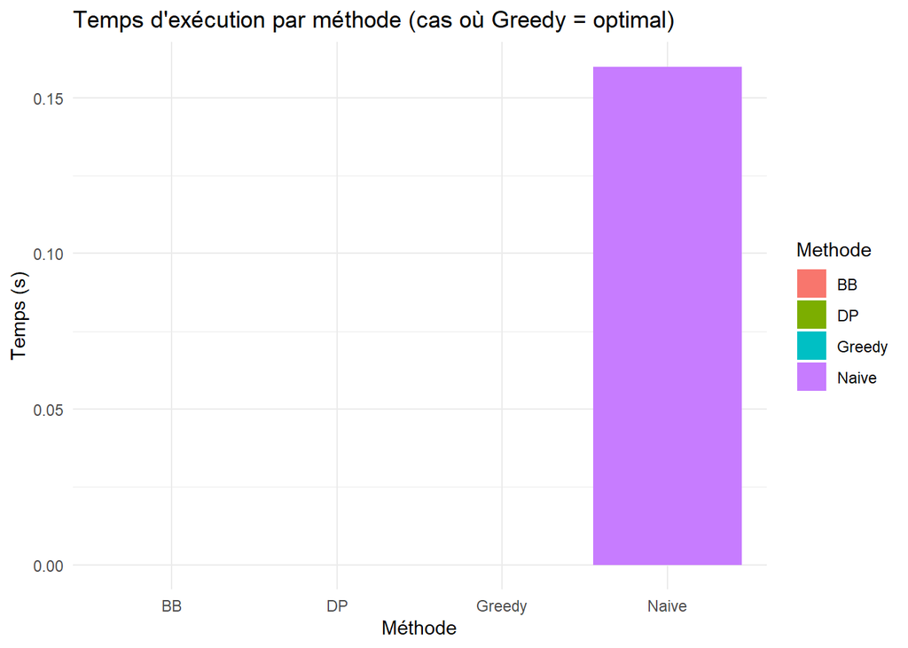

```r
if (!is.null(case_equal)) {
  library(ggplot2)
  ggplot(case_equal$times, aes(x = Methode, y = Temps_s, fill = Methode)) +
    geom_col() +
    labs(
      title = "Temps d'exécution par méthode (cas où Greedy = optimal)",
      x = "Méthode",
      y = "Temps (s)"
    ) +
    theme_minimal()
}
```

# Cas ou la méthode approchée performe moins que les méthodes exactes :

```r
find_case_greedy_worse <- function(n_students = 8, n_formations = 3,
                                   max_seed = 1000) {
  for (s in 1:max_seed) {
    inst <- generate_instance(n_students, n_formations, seed = s)

    # Scores des 4 méthodes
    df <- compare_methods_one_instance(inst)

    score_opt    <- max(df$Score[ df$Methode %in% c("Naive", "BB", "DP") ], na.rm = TRUE)
    score_greedy <- df$Score[df$Methode == "Greedy"]

    # On cherche un cas où Greedy est strictement plus mauvais
    if (!is.na(score_greedy) && (score_greedy + 1e-9) < score_opt) {
      cat("Trouvé : seed =", s, "\n")
      print(df)

      # ==== Mesure des temps sur CETTE instance ====
      safe_time <- function(fun) {
        t <- system.time( invisible(fun()) )
        as.numeric(t[["elapsed"]])
      }

      t_naive  <- safe_time(function() solution_naive_simple(
        inst$scores, inst$capacities, inst$notes, inst$notes_min
      ))
      t_bb     <- safe_time(function() solution_bb(
        inst$scores, inst$capacities, inst$notes, inst$notes_min
      ))
      t_dp     <- safe_time(function() solution_dp(
        inst$scores, inst$capacities, inst$notes, inst$notes_min
      ))
      t_greedy <- safe_time(function() solution_greedy(
        inst$scores, inst$capacities, inst$notes, inst$notes_min
      ))

      times_df <- data.frame(
        Methode = c("Naive", "BB", "DP", "Greedy"),
        Temps_s = c(t_naive, t_bb, t_dp, t_greedy)
      )

      cat("\nTemps d'exécution (en secondes) sur cette instance :\n")
      print(times_df)

      return(list(
        seed     = s,
        instance = inst,
        scores   = df,
        times    = times_df
      ))
    }
  }
  cat("Aucun cas trouvé (augmenter max_seed).\n")
  NULL
}

case_worse <- find_case_greedy_worse(n_students = 8, n_formations = 3, max_seed = 500)
```

```
## Trouvé : seed = 2
##   Methode     Score
## 1   Naive 1279.9293
## 2      BB 1279.9293
## 3      DP 1279.9293
## 4  Greedy  954.4153
##
## Temps d'exécution (en secondes) sur cette instance :
##   Methode Temps_s
## 1   Naive    0.17
## 2      BB    0.00
## 3      DP    0.00
## 4  Greedy    0.00
```

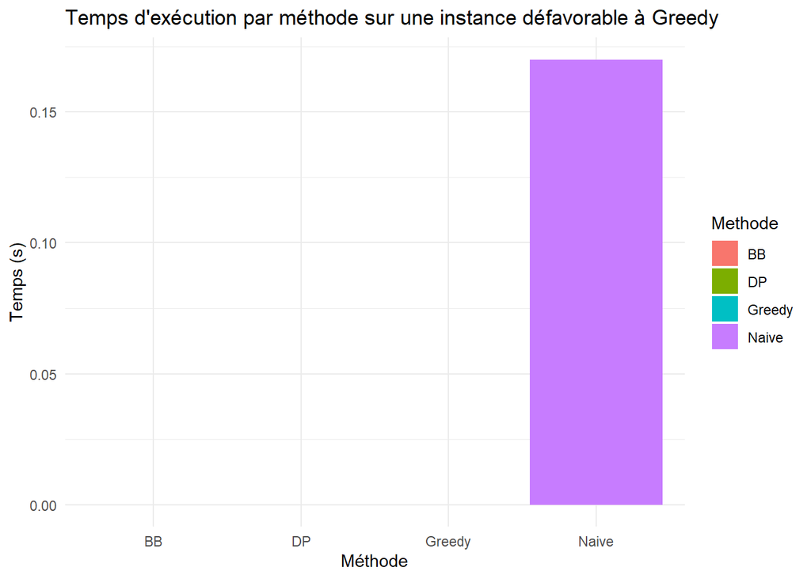

```r
if (!is.null(case_worse)) {
  library(ggplot2)
  ggplot(case_worse$times, aes(x = Methode, y = Temps_s, fill = Methode)) +
    geom_col() +
    labs(
      title = "Temps d'exécution par méthode sur une instance défavorable à Greedy",
      x = "Méthode",
      y = "Temps (s)"
    ) +
    theme_minimal()
}
```

# Démonstration par simulation de la complexité des méthodes :

```r
library(dplyr)
```

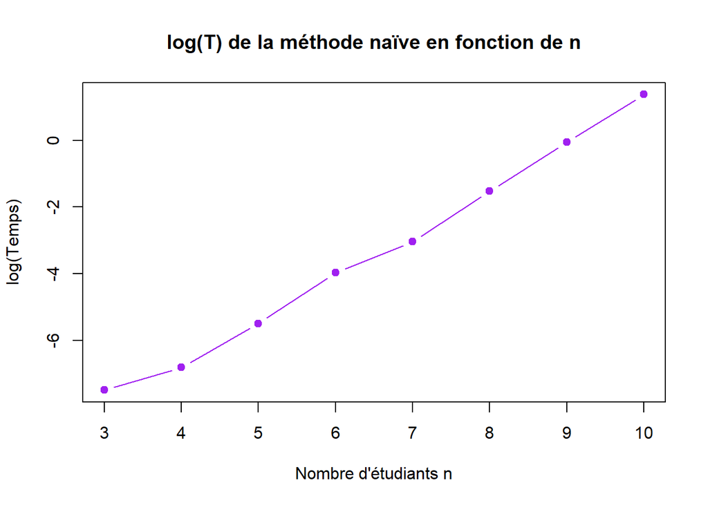

```r
time_naive_only <- function(n_students, n_formations = 3,
                            n_rep = 3, time_limit = 5) {

  mesures <- numeric(n_rep)

  for (r in 1:n_rep) {
    inst <- generate_instance(n_students, n_formations,
                              seed = 5000 + 10*n_students + r)

    safe_time <- function(fun) {
      start <- Sys.time()
      out <- tryCatch(fun(), error = function(e) NULL)
      end <- Sys.time()
      dt <- as.numeric(difftime(end, start, units = "secs"))
      if (dt > time_limit) NA_real_ else dt
    }

    mesures[r] <- safe_time(function() {
      solution_naive_simple(inst$scores, inst$capacities,
                            inst$notes, inst$notes_min)
    })
  }

  mean(mesures, na.rm = TRUE)
}
n_values_naive <- 3:10

times_naive <- sapply(n_values_naive, function(n) {
  time_naive_only(n, n_formations = 3, n_rep = 3)
})

df_naive <- data.frame(
  n = n_values_naive,
  Temps_moyen = times_naive
)
plot(df_naive$n, log(df_naive$Temps_moyen),
     type = "b", pch = 19, col = "purple",
     main = "log(T) de la méthode naïve en fonction de n",
     xlab = "Nombre d'étudiants n", ylab = "log(Temps)")
```

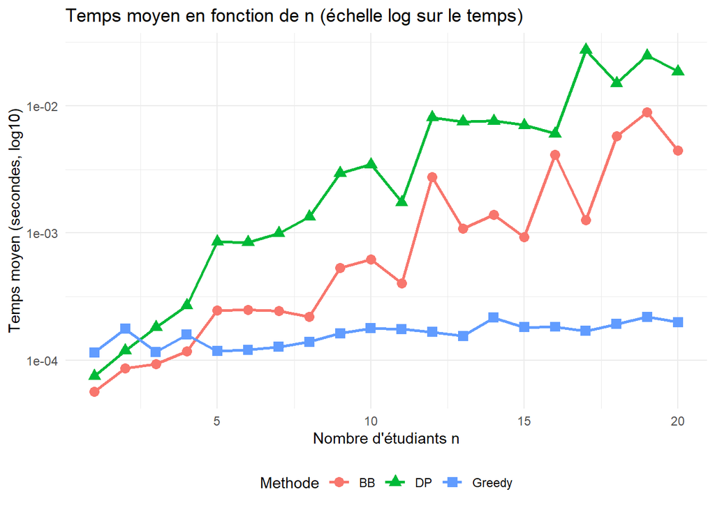

```r
time_one_n <- function(n_students, n_formations = 3,
                       n_rep = 5, time_limit = 5) {
  # n_rep = nombre de répétitions pour moyenner

  mesures <- data.frame(
    n = integer(0),
    Methode = character(0),
    Temps = numeric(0),
    stringsAsFactors = FALSE
  )

  for (r in 1:n_rep) {
    inst <- generate_instance(n_students, n_formations, seed = 1000 + 10*n_students + r)

    # petite fonction pour mesurer un temps sécurisé
    safe_time <- function(fun) {
      start <- Sys.time()
      out <- tryCatch({
        fun()
      }, error = function(e) NULL)
      end <- Sys.time()
      dt <- as.numeric(difftime(end, start, units = "secs"))
      if (dt > time_limit) NA_real_ else dt
    }

    #t_naive  <- safe_time(function() solution_naive_simple(inst$scores, inst$capacities, inst$notes, inst$notes_min))
    t_bb     <- safe_time(function() solution_bb(inst$scores, inst$capacities, inst$notes, inst$notes_min))
    t_dp     <- safe_time(function() solution_dp(inst$scores, inst$capacities, inst$notes, inst$notes_min))
    t_greedy <- safe_time(function() solution_greedy(inst$scores, inst$capacities, inst$notes, inst$notes_min))

    mesures <- rbind(
      mesures,
      #data.frame(n = n_students, Methode = "Naive",  Temps = t_naive),
      data.frame(n = n_students, Methode = "BB",     Temps = t_bb),
      data.frame(n = n_students, Methode = "DP",     Temps = t_dp),
      data.frame(n = n_students, Methode = "Greedy", Temps = t_greedy)
    )
  }

  mesures
}

# Boucle sur plusieurs n
n_values <- 1:20
all_times <- do.call(rbind, lapply(n_values, function(n) time_one_n(n, n_formations = 3, n_rep = 3)))

library(ggplot2)

times_mean <- all_times %>%
  group_by(n, Methode) %>%
  summarise(Temps_moyen = mean(Temps, na.rm = TRUE), .groups = "drop") %>%
  filter(!is.na(Temps_moyen))

ggplot(times_mean, aes(x = n, y = Temps_moyen, color = Methode, shape = Methode)) +
  geom_point(size = 3) +
  geom_line(size = 1) +
  scale_y_log10() +
  labs(
    title = "Temps moyen en fonction de n (échelle log sur le temps)",
    x = "Nombre d'étudiants n",
    y = "Temps moyen (secondes, log10)"
  ) +
  theme_minimal() +
  theme(legend.position = "bottom")
```

# Justification de la complexité par la simulation : - **Naive** : Pour vérifier expérimentalement la nature exponentielle de la méthode naïve, nous avons ajusté un modèle linéaire de la forme :
$$\log(T(n)) = a + b\,n.$$

```r
# Régression linéaire sur log(Temps_moyen) en fonction de n (méthode naïve)
model_naive <- lm(log(Temps_moyen) ~ n, data = df_naive)
summary(model_naive)
```

```
##
## Call:
## lm(formula = log(Temps_moyen) ~ n, data = df_naive)
##
## Residuals:
##      Min       1Q   Median       3Q      Max
## -0.31363 -0.18118 -0.01709  0.12041  0.41332
##
## Coefficients:
##              Estimate Std. Error t value Pr(>|t|)
## (Intercept) -11.77896    0.27789  -42.39 1.15e-08 ***
## n             1.29314    0.04032   32.07 6.11e-08 ***
## ---
## Signif. codes:  0 '***' 0.001 '**' 0.01 '*' 0.05 '.' 0.1 ' ' 1
##
## Residual standard error: 0.2613 on 6 degrees of freedom
## Multiple R-squared:  0.9942, Adjusted R-squared:  0.9932
## F-statistic:  1029 on 1 and 6 DF,  p-value: 6.109e-08
```

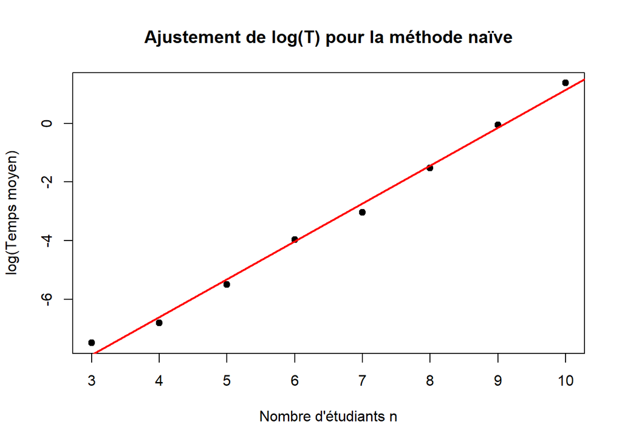

```r
plot(df_naive$n, log(df_naive$Temps_moyen),
     pch = 19,
     main = "Ajustement de log(T) pour la méthode naïve",
     xlab = "Nombre d'étudiants n",
     ylab = "log(Temps moyen)")

abline(model_naive, col = "red", lwd = 2)
```

**Branch and bound** :

```r
df_bb <- times_mean[times_mean$Methode == "BB", ]
model_bb <- lm(log(Temps_moyen) ~ n, data = df_bb)
summary(model_bb)
```

```
##
## Call:
## lm(formula = log(Temps_moyen) ~ n, data = df_bb)
##
## Residuals:
##      Min       1Q   Median       3Q      Max
## -0.88155 -0.17127 -0.06399  0.23619  1.10268
##
## Coefficients:
##             Estimate Std. Error t value Pr(>|t|)
## (Intercept) -9.90214    0.22496  -44.02  < 2e-16 ***
## n            0.24181    0.01878   12.88 1.61e-10 ***
## ---
## Signif. codes:  0 '***' 0.001 '**' 0.01 '*' 0.05 '.' 0.1 ' ' 1
##
## Residual standard error: 0.4843 on 18 degrees of freedom
## Multiple R-squared:  0.9021, Adjusted R-squared:  0.8966
## F-statistic: 165.8 on 1 and 18 DF,  p-value: 1.609e-10
```

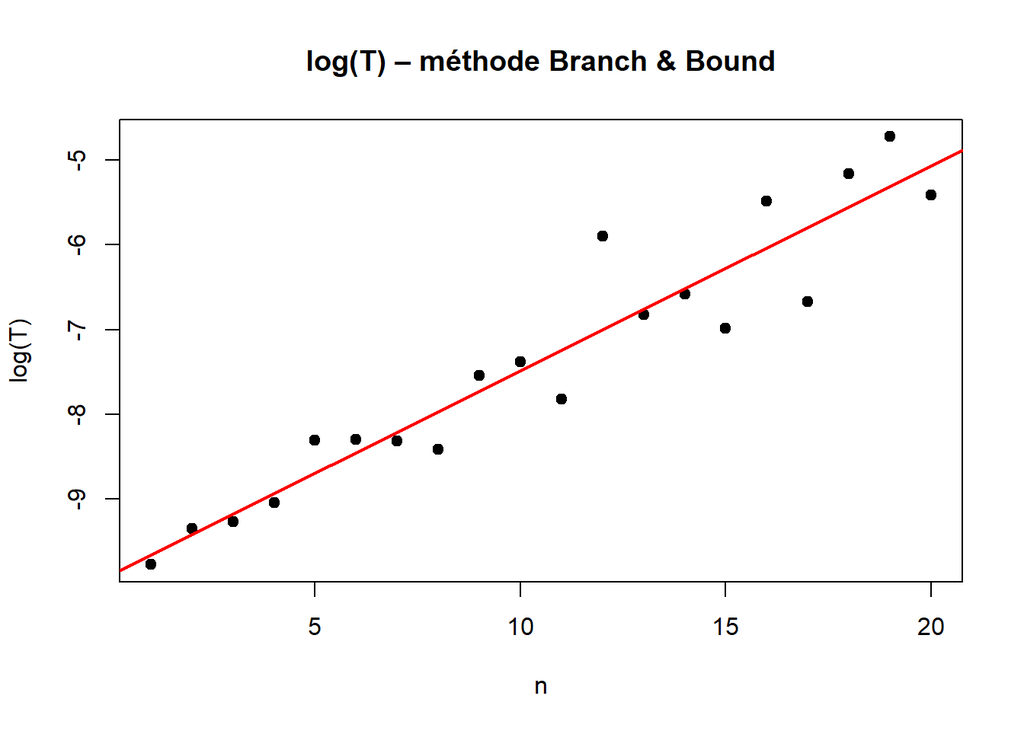

```r
plot(df_bb$n, log(df_bb$Temps_moyen),
     pch=19, main="log(T) – méthode Branch & Bound",
     xlab="n", ylab="log(T)")
abline(model_bb, col="red", lwd=2)
```

Pour la méthode Branch & Bound, nous avons ajusté un modèle $\log T(n) = a + b n$. Comme pour la méthode naïve, la courbe en échelle logarithmique est quasi linéaire, ce qui traduit une croissance exponentielle en $n$. En revanche, la pente $b$ est nettement plus faible que pour la méthode naïve, ce qui montre que l’élagage réduit fortement le facteur de branchement effectif. Branch & Bound reste donc exponentielle dans le pire cas, mais beaucoup plus efficace en pratique.

**Programmation Dynamique** :

```r
# Mesure le temps de la méthode DP pour un (n, m) donné,
# avec capacités forcées à une petite valeur (ex: 3)
time_dp_fixed_cap <- function(n_students,
                              n_formations,
                              cap_val = 3,
                              n_rep = 3,
                              time_limit = 10) {

  temps <- numeric(n_rep)

  for (r in 1:n_rep) {
    # Génération standard
    inst <- generate_instance(
      n_students   = n_students,
      n_formations = n_formations,
      seed         = 7000 + 100*n_formations + r
    )

    # On force les capacités à une valeur fixe pour isoler l'effet de m
    capacities_fixed <- rep(cap_val, n_formations)

    # Sécurité temps
    safe_time <- function(fun) {
      start <- Sys.time()
      out <- tryCatch(fun(), error = function(e) NULL)
      end <- Sys.time()
      dt <- as.numeric(difftime(end, start, units = "secs"))
      if (dt > time_limit) NA_real_ else dt
    }

    temps[r] <- safe_time(function() {
      solution_dp(
        inst$scores,
        capacities_fixed,
        inst$notes,
        inst$notes_min
      )
    })
  }

  mean(temps, na.rm = TRUE)
}

# Paramètres de test
n_students <- 8             # nombre d'étudiants fixé
m_values   <- 1:8           # on fait varier m
cap_val    <- 3             # capacité fixe par formation
n_rep      <- 3             # répétitions pour moyenner

# Mesure des temps pour chaque m
times_dp_m <- sapply(m_values, function(m) {
  time_dp_fixed_cap(
    n_students   = n_students,
    n_formations = m,
    cap_val      = cap_val,
    n_rep        = n_rep,
    time_limit   = 10
  )
})

df_dp_m <- data.frame(
  m           = m_values,
  Temps_moyen = times_dp_m
)

df_dp_m
```

```
##   m  Temps_moyen
## 1 1 0.0003244082
## 2 2 0.0009113948
## 3 3 0.0018761158
## 4 4 0.0047036807
## 5 5 0.0085440477
## 6 6 0.0224813620
## 7 7 0.0336056550
## 8 8 0.4679766496
```

```r
# Filtrer les valeurs valides (au cas où certaines soient NA)
df_dp_m_clean <- df_dp_m[!is.na(df_dp_m$Temps_moyen), ]

# Régression linéaire : log(T) ~ m
model_dp_m <- lm(log(Temps_moyen) ~ m, data = df_dp_m_clean)
summary(model_dp_m)
```

```
##
## Call:
## lm(formula = log(Temps_moyen) ~ m, data = df_dp_m_clean)
##
## Residuals:
##      Min       1Q   Median       3Q      Max
## -0.76209 -0.26007  0.02048  0.12680  0.95492
##
## Coefficients:
##             Estimate Std. Error t value Pr(>|t|)
## (Intercept) -9.04796    0.41463  -21.82 6.05e-07 ***
## m            0.91671    0.08211   11.16 3.08e-05 ***
## ---
## Signif. codes:  0 '***' 0.001 '**' 0.01 '*' 0.05 '.' 0.1 ' ' 1
##
## Residual standard error: 0.5321 on 6 degrees of freedom
## Multiple R-squared:  0.9541, Adjusted R-squared:  0.9464
## F-statistic: 124.7 on 1 and 6 DF,  p-value: 3.08e-05
```

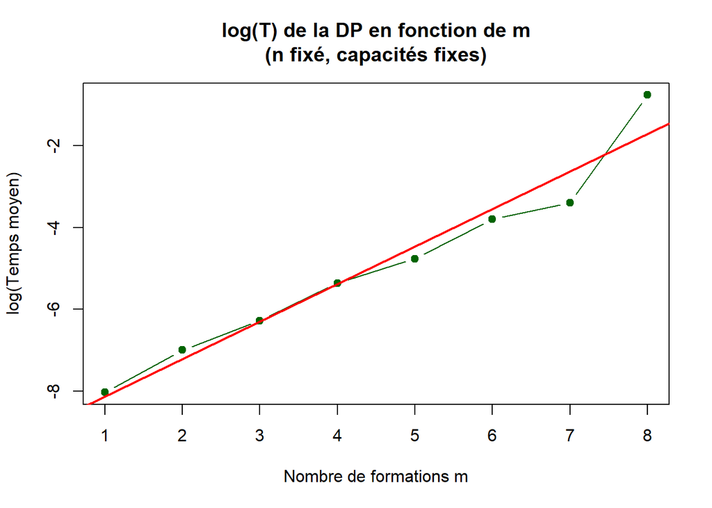

```r
# Plot
plot(df_dp_m_clean$m, log(df_dp_m_clean$Temps_moyen),
     type = "b",
     pch  = 19,
     col  = "darkgreen",
     main = "log(T) de la DP en fonction de m\n(n fixé, capacités fixes)",
     xlab = "Nombre de formations m",
     ylab = "log(Temps moyen)")

abline(model_dp_m, col = "red", lwd = 2)
```

Lorsque l’on fixe le nombre d’étudiants et que l’on fait varier le nombre de formations $m$, la complexité de la programmation dynamique devient essentiellement $\mathcal{O}\!\left((C+1)^m\right)$.

En traçant $\log(T)$ en fonction de $m$, on obtient une relation presque linéaire, ce qui confirme expérimentalement une croissance exponentielle du temps d’exécution. La droite de régression s’ajuste bien à la tendance générale, malgré quelques fluctuations liées au caractère aléatoire des instances et aux faibles valeurs de $m$.

Cette expérience valide donc la dépendance exponentielle de la méthode de programmation dynamique par rapport au nombre de formations $m$.

**Gloutonne**: Bien que la complexité théorique de la méthode gloutonne soit $O(n\,m\log(nm))$, la croissance observée expérimentalement apparaît presque linéaire. Cela s’explique par le fait que le terme $\log(nm)$ varie très peu dans la plage de valeurs utilisée. Ainsi, $nm\log(nm)$ se comporte numériquement comme une fonction presque proportionnelle à $nm$.

De plus, lorsque l’on trace $\log(T(n))$, on obtient :
$$\log T(n) = \log(nm) + \log(\log(nm)),$$
deux fonctions qui évoluent extrêmement lentement. Ceci produit une courbe pratiquement linéaire, sans indiquer pour autant une croissance exponentielle. Ces résultats confirment que la méthode gloutonne demeure polynomiale et très efficace, même si sa complexité théorique inclut un facteur logarithmique.

# VI - Implémentations en Rcpp : R vs C++

```r
remotes::install_github("agossadourin/ParcoursupM2Algorithmique")
library(Rcpp)
library(ParcoursupM2Algorithmique)
```

```r
library(microbenchmark)
set.seed(123)
# Génération d'une "grosse" instance

make_big_instance <- function(n_students = 22, n_formations = 5, seed = 2024) {
  inst <- generate_instance(n_students, n_formations, seed = seed)

  # matrice des notes pour le C++ (n x m), chaque colonne = notes de tous les étudiants
  notes_mat <- matrix(
    rep(inst$notes, times = n_formations),
    nrow = n_students,
    ncol = n_formations
  )

  list(inst = inst, notes_mat = notes_mat)
}

big <- make_big_instance(n_students = 22, n_formations = 5, seed = 2024)

inst      <- big$inst
notes_mat <- big$notes_mat

scores    <- inst$scores
capacites <- as.integer(inst$capacities)
notes_vec <- as.numeric(inst$notes)
notes_min <- as.numeric(inst$notes_min)
n_big     <- inst$n_students
m_big     <- inst$n_formations

cat("Instance utilisée : n =", n_big, "étudiants ; m =", m_big, "formations\n")
```

```
## Instance utilisée : n = 22 étudiants ; m = 5 formations
```

```r
bench_bb <- microbenchmark(
  BB_R   = solution_bb(scores, capacites, notes_vec, notes_min),
  BB_Cpp = solution_bb_cpp(scores, capacites, notes_mat, notes_min),
  times  = 30L
)



bench_dp <- microbenchmark(
  DP_R   = solution_dp(scores, capacites, notes_vec, notes_min),
  DP_Cpp = solution_dp_cpp(scores, capacites, notes_mat, notes_min),
  times  = 30L
)



bench_greedy <- microbenchmark(
  Greedy_R   = solution_greedy(scores, capacites, notes_vec, notes_min),
  Greedy_Cpp = solution_greedy_cpp(scores, capacites, notes_mat, notes_min),
  times      = 30L
)



# fonction utilitaire pour extraire la moyenne (en millisecondes)
mean_ms <- function(bench, expr_name) {
  m <- mean(bench$time[bench$expr == expr_name])
  m / 1e6   # microbenchmark donne des nanosecondes
}

res_perf <- data.frame(
  Methode = c("BB", "DP", "Greedy"),
  R_ms    = c(
    mean_ms(bench_bb,     "BB_R"),
    mean_ms(bench_dp,     "DP_R"),
    mean_ms(bench_greedy, "Greedy_R")
  ),
  Cpp_ms  = c(
    mean_ms(bench_bb,     "BB_Cpp"),
    mean_ms(bench_dp,     "DP_Cpp"),
    mean_ms(bench_greedy, "Greedy_Cpp")
  )
)

res_perf$Speedup_Cpp_vs_R <- res_perf$R_ms / res_perf$Cpp_ms

res_perf
```

```
##   Methode         R_ms      Cpp_ms Speedup_Cpp_vs_R
## 1      BB   17.6454467  0.06225333        283.44581
## 2      DP 1467.8128833 30.67690667         47.84749
## 3  Greedy    0.2435167  0.01675667         14.53252
```

Dans l’ensemble, ces résultats confirment que les méthodes intensives en boucles, récursion ou mises à jour de structures bénéficient fortement du passage au C++, qui élimine la surcharge interprétative et optimise l’allocation mémoire, conduisant à des gains pouvant dépasser deux ordres de grandeur.